# Code_chunk

Paradise

2018年11月22日

## Options of Code Chunks

**knitr**提供了近60个参数选项用于自定义chunk的输出

通过以下网址可以查看全部的options:http://yihui.name/knitr/options/.

这里展示比较常用的重要的options

```r
x<-runif(10)
y<-runif(10)
x
```

```
>  [1] 0.62342719 0.99018785 0.14581361 0.47772557 0.05882587 0.98083123
>  [7] 0.35680228 0.80947740 0.27125853 0.93749681
```

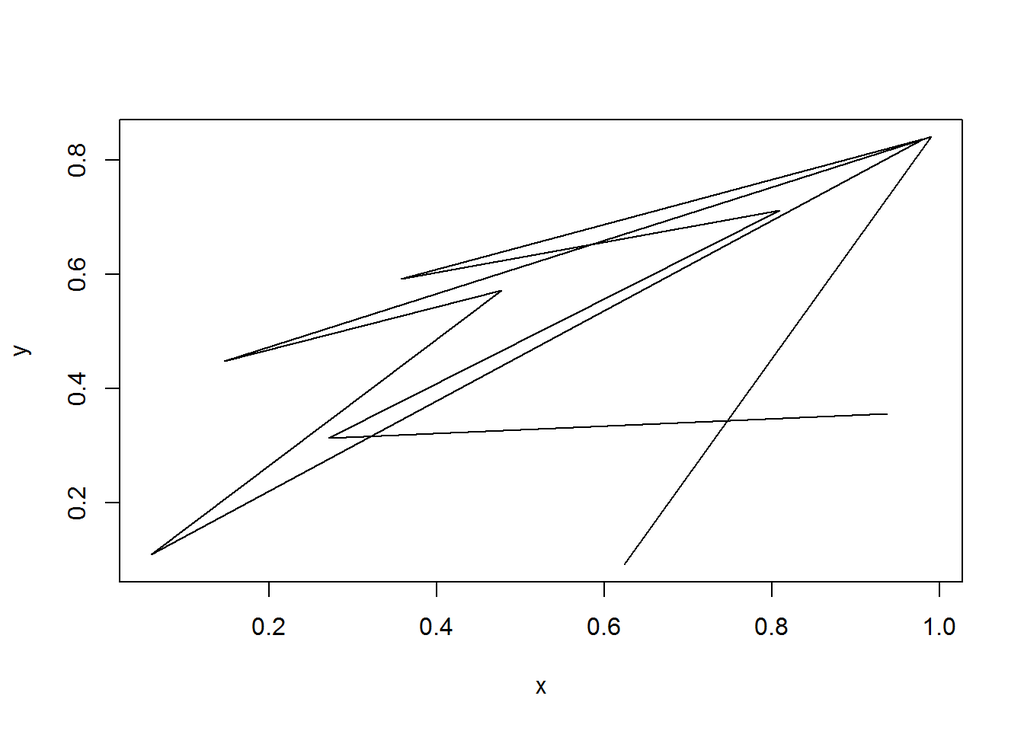

```r
plot(x,y,type="l")
```

## `说明`

- 使用eval=FALSE，（当代码块有error仍能）输出代码，但是输出文件不包含执行结果
- 使用include=FALSE，运行代码，但是不在输出文件里显示代码或输出结果
- 使用echo=FALSE，输出执行结果，但是不包含源代码
- 使用message=FALSE或者warning=FALSE，输出文件中不包含warning信息
- 使用result=’hide’隐藏打印输出的内容，使用fig.show=’hide’隐藏图形输出
- 使用error=TRUE，即使有代码块报错也继续输出文件，在调试阶段使用

## Table

默认情况下数据框输出跟在console的输出格式一样，使用kable函数可以输出表格格式

```r
mtcars[1:5,1:10]
```

```
>                    mpg cyl disp  hp drat    wt  qsec vs am gear
> Mazda RX4         21.0   6  160 110 3.90 2.620 16.46  0  1    4
> Mazda RX4 Wag     21.0   6  160 110 3.90 2.875 17.02  0  1    4
> Datsun 710        22.8   4  108  93 3.85 2.320 18.61  1  1    4
> Hornet 4 Drive    21.4   6  258 110 3.08 3.215 19.44  1  0    3
> Hornet Sportabout 18.7   8  360 175 3.15 3.440 17.02  0  0    3
```

```r
knitr::kable(mtcars[1:5,1:10],
             caption = "A knitr table")
```

A knitr table

|  | mpg | cyl | disp | hp | drat | wt | qsec | vs | am | gear |
| --- | --- | --- | --- | --- | --- | --- | --- | --- | --- | --- |
| Mazda RX4 | 21.0 | 6 | 160 | 110 | 3.90 | 2.620 | 16.46 | 0 | 1 | 4 |
| Mazda RX4 Wag | 21.0 | 6 | 160 | 110 | 3.90 | 2.875 | 17.02 | 0 | 1 | 4 |
| Datsun 710 | 22.8 | 4 | 108 | 93 | 3.85 | 2.320 | 18.61 | 1 | 1 | 4 |
| Hornet 4 Drive | 21.4 | 6 | 258 | 110 | 3.08 | 3.215 | 19.44 | 1 | 0 | 3 |
| Hornet Sportabout | 18.7 | 8 | 360 | 175 | 3.15 | 3.440 | 17.02 | 0 | 0 | 3 |

## `说明`

- 执行**?knitr::kable**了解很多更细致的自定义表格输出的方法
- 更深入的格式显示方法，可以使用**xtable**,**stargazer**,**pander**,**tables**以及**ascii**等包

## Caching

```
为了实现可再现性，所有的输出内容都是从空白页面开始构建，以确保代码里包含所有重要信息。
```

但是当代码块里面有计算量较大的指令，那就需要用到缓存：定义cache=TRUE。 设置缓存时，计算结果会保存到特定文件，下一次执行时，如果代码块没有改变，则引用该缓存文件。

```r
rawdata<-readr::read_csv("a_very_large_file.csv")
```

注意例子只是样本代码，设置了eval=FAlSE，不执行

```r
processing the terribly large data
```

此处注意，如果没有定义dependson=“raw_data”，那么即使读取的csv文件改变了， 只要‘processing’没有改变，仍然不会重新执行该代码块，而是直接使用缓存。

如果担心“a_very_large_file.csv”文件内容本身发生改变，导致后续的代码使用缓存而出错，可以在 raw_data代码块增加cache.extra=file.info(“file_name”)这样可以检查文件的相关信息，包括最后一次 修改的时间。

```r
knitr::clean_cache()
```

使用上述指令可以清除所有的缓存（当缓存的文件越来越复杂混乱的时候）

## Global Options

`关于全局设置的内容在第五部分的script中出现`

## Inline Code

直接在文本中间引用并嵌入R代码，knit之后以执行结果的形式显示

For example,we have data about **53940** diamonds.

在文本中嵌入数字的时候，最好设置精确度，以及在大数中插入逗号(使用**format**函数)

```r
a<-1234567
format(a,big.mark = ",")
```

```
> [1] "1,234,567"
```

```r
b<-0.1234567
format(b,digits = 2)
```

```
> [1] "0.12"
```